# Midterm

### Estimation

**Problem 11**. Suppose that we are doing a simple form gradient optimization, where the parameters we're optimizing only take on specific values (i.e. we're optimizing on a grid, not on the entire real space). Let's say we're optimizing over two parameters, $p_1$ and $p_2$. Suppose that the cost function values (e.g. sum of squares) for each grid point are shown in the figure below, and we start with $p_1 = 0.1$ and $p_2 = 5$ (marked in bold blue). Assume that our optimization algorithm is attempting to *minimize* the cost function at each next step, and can only move up/down/left/right (along the lines of the grid), not diagonally.

- **(a)** From our starting position, what path does our optimization algorithm take? Draw or write down the sequence of $p_1$ and $p_2$ values that the optimization algorithm will try, and what the final values of $p_1$, $p_2$, and the cost function are. Store the final values into 'a_p1' 'a_p2' and 'a_cost' for the autograder.
- **(b)** Did the algorithm find the best parameter values? What are the overall best fit values for $p_1$ and $p_2$ across the entire grid space shown? Store into 'b_p1' and 'b_p2'.
- **(c)** How many local minima on this grid are there? Give the $p_1$ and $p_2$ values for each local minimum in the space.
- **(d)** How might you adapt the optimization algorithm to ensure that it doesn't get trapped in a local minimum? (You don't have to implement this! Just describe an idea or two)

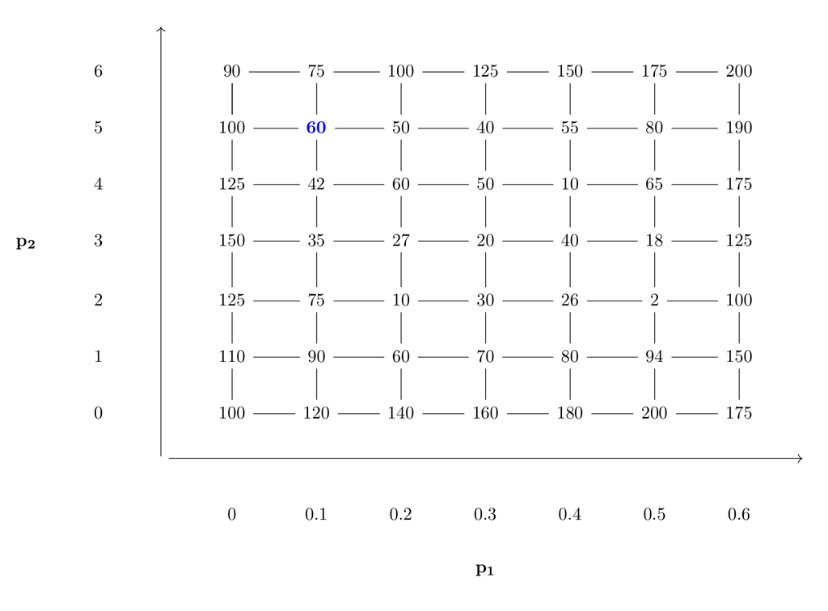

```python
a_p1 = a_p2 = a_cost = b_p1 = b_p2 = 0
###
### YOUR CODE HERE
###
```

```python
###
### AUTOGRADER TEST - DO NOT REMOVE
###
```

**Problem 12**. Suppose we are fitting a linear model to data on cancer incidence as a function of cigarette smoking patterns. Our model is given by: $$ y = mx + b$$ where $y$ is the percent of individuals who develop cancer and $x$ is the number of cigarettes per day smoked, $m$ is the slope parameter representing the increase in cancer risk per daily cigarette smoked, and $b$ is the baseline cancer risk among non-smokers (people who smoke $0$ cigarettes/day).

- **a)** Calculate the sum of squared residuals (sum of squares) for the model and this data fit using the data in the table. If you want to do this with python, the data values are given as a numpy array in the code chunk below, so you can use that data (otherwise calculating by hand/with excel/etc. is also fine). Store into 'part_a' and round to 2 decimal places for the autograder.
- **b)** Look at the fit of the model (line) to the data (circles). Does it look like the model fits the data well? Why or why not?
- **c)** How might you improve this model? There are multiple possible right answers here---are there ways you could improve the model fit to the data? Are there variables that you might want to add to the model that aren't currently included? (There are many possible right answers to this question)
- **d)** Lastly, try to rewrite the cost function to be the likelihood function, supposing that each data point is independent, and we assume the data are drawn from a normal distribution where the mean is our model prediction $y$ and the standard deviation is known to be $0.01$. Since likelihoods were one of the last topics that we covered, we will grade this generously! Just give it your best shot. You don't need to evaluate the likelihood using this data, just write down the mathematical form that it takes.

  You can write out the likelihood using the formula for the [normal distribution probability density function](https://en.wikipedia.org/wiki/Normal_distribution), or even if you just write $\mathcal{Normal}(\mu, \sigma)$ where $\mu$ is the mean and $\sigma$ is the standard deviation, that's okay too.

[output not shown]

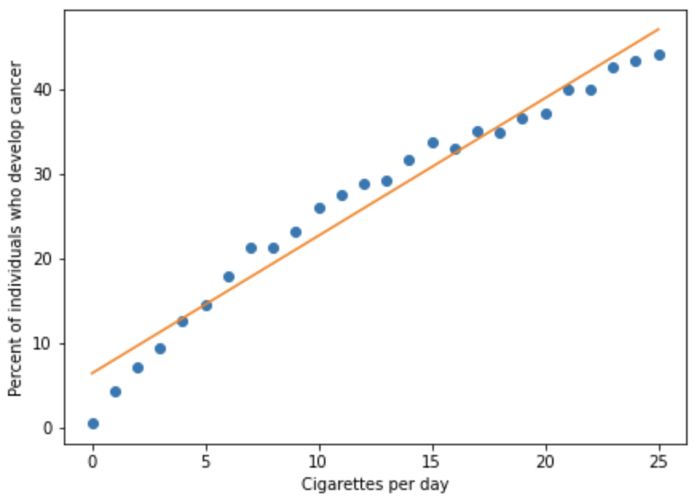

```python
# Data sets in case you want to use them for coding:

# Data on cigarettes smoked per day (x axis values)
cigdata = np.linspace(0,22,12)

# Data on percent of individuals who develop cancer (y axis circle values)
cancerdata = np.array([0.5,7.7, 12.8, 16.9, 21.4, 24.5, 28.8, 33.,  33.8, 36.2, 39.6, 41.6])

# Model prediction of percent of individuals who develop cancer (y axis line values)
modelpred = np.array([ 5.,8.6, 12.2, 15.7, 19.3, 22.9, 26.5, 30.1, 33.7, 37.3, 40.9, 44.5])
```

```python
part_a = 0
###
### YOUR CODE HERE
###
```

```python
###
### AUTOGRADER TEST - DO NOT REMOVE
###
```